# BIOS 667 - Lecture 3: Overview of Linear Models for Longitudinal Data (Ch. 3)

Fitzmaurice, Laird & Ware (2011) - Applied Longitudinal Data Analysis

Naim Rashid

# Lecture Objectives

## By the End of This Lecture, You Will Be Able To

- Define and use **vector and matrix notation** for longitudinal data
- Specify the **general linear model** with mean and covariance components
- Apply **descriptive visualization methods** to explore longitudinal patterns
- Compare **three covariance modeling approaches**: unstructured, pattern models, and random effects
- Explain limitations of **historical approaches** (summary measures, ANOVA, MANOVA)

## How These Objectives Map to Your Work

| Objective | Where you use it |
| --- | --- |
| Vector/matrix notation | Every later lecture; HW1 setup of $\mathbf{Y}_i$, $\mathbf{X}_i$ |
| General linear model (mean + covariance) | LME and GEE on HW3-HW4; final project model specification |
| Descriptive visualization | HW1 exploratory plots; first step of the final-project analysis |
| Three covariance approaches | Motivates covariance-pattern (Ch. 7) and random-effects (Ch. 8) choices on HW3 |
| Limits of historical approaches | Justifies why the final project uses modern methods, not ANOVA/MANOVA |

# Roadmap

## Lecture Overview

| Section | Topics |
| --- | --- |
| **Part 1** | Notation and distributional assumptions |
| **Part 2** | Descriptive methods for visualization |
| **Part 3** | Modeling the covariance structure |
| **Part 4** | Historical approaches and their limitations |
| **Part 5** | Summary and next steps |

## Prerequisites / recall

You will get the most out of this lecture if you are comfortable with:

- **Column vectors and matrices**: stacking values into a vector, reading matrix dimensions
- **The design matrix** and the regression form $\mathbf{X}\boldsymbol\beta$ in matrix notation (from Lecture 2)
- **Transpose** notation ($\mathbf{X}^\top$) and **block-diagonal** matrices
- The **multivariate normal** distribution as the multivariate analogue of the normal

We build directly on the $\mathbf{X}\boldsymbol\beta$ matrix form from L02; today we add the within-subject covariance.

## Notation reference (so far)

| Symbol | Meaning |
| --- | --- |
| $i,\ j$ | subject index $i = 1,\dots,N$ and occasion/time index $j = 1,\dots,n_i$ |
| $N,\ n_i$ | number of subjects; number of occasions for subject $i$ ($n$ when balanced) |
| $Y_{ij},\ \mathbf{Y}_i$ | response for subject $i$ at occasion $j$ (scalar); response vector $(n_i \times 1)$ |
| $t_{ij}$ | measurement time for subject $i$ at occasion $j$ |
| $X_{ij},\ \mathbf{X}_i$ | covariate row vector $1 \times p$; design matrix $n_i \times p$ |
| $\boldsymbol\beta$ | fixed-effect (population-average) coefficients |
| $\varepsilon_{ij},\ \boldsymbol\varepsilon_i$ | residual error (scalar; vector) |
| $\Sigma_i = \operatorname{Cov}(\mathbf{Y}_i)$ | marginal (total) covariance of $\mathbf{Y}_i$ (decomposes into random-effect + residual parts once random effects appear, Ch. 8) |
| $\rho$ | a correlation parameter (e.g. exchangeable, or AR(1) where corr at lag $k$ is $\rho^k$) |

**Bold** = vector or matrix. This is a running reference card: later lectures add random-effect and GEE notation.

# Part 1: Notation and Distributional Assumptions

## The Response Vector $\mathbf{Y}_i$

$Y_{ij}$ denotes the response for subject $i$ at occasion $j$.

We group the $n_i$ repeated measures for subject $i$ into a column vector:

$$\mathbf{Y}_{i} = \begin{pmatrix} Y_{i1} \\ Y_{i2} \\ \vdots \\ Y_{in_{i}} \end{pmatrix}_{n_i \times 1}$$

## Independence Structure

| Level | Independence? |
| --- | --- |
| Between subjects | Yes (conditional on covariates) |
| Within subject | No (repeated measures are correlated) |

This within-subject correlation is the defining feature of longitudinal data.

## The Covariate Matrix $\mathbf{X}_{i}$

$X_{ij}$ is the $1 \times p$ **row vector** of covariates for subject $i$ at occasion $j$. Stacking these rows over the $n_i$ occasions gives the **design matrix** for subject $i$:

$$\mathbf{X}_{i} = \begin{pmatrix} X_{i1} \\ X_{i2} \\ \vdots \\ X_{in_{i}} \end{pmatrix}_{n_i \times p}$$

So $\mathbf{X}_i$ is $n_i \times p$, and the model is written $\mathbf{X}_i\boldsymbol\beta$.

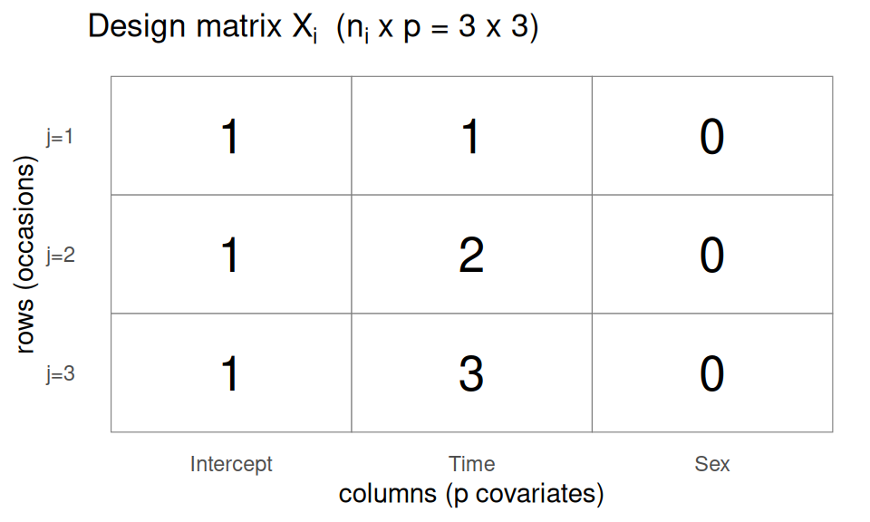

Rows are occasions, columns are covariates. Intercept is a column of 1s; Sex is constant (time-constant); Time increases down the rows (time-varying).

## Covariate Types

| Type | Description | Example |
| --- | --- | --- |
| Time-constant | Does not change over time | Sex, race |
| Time-varying | Changes at each occasion | Age, weight |

## The General Linear Model

The model for the observation vector of subject $i$ is:

$$\mathbf{Y}_{i} = \mathbf{X}_{i}\boldsymbol{\beta} + \boldsymbol{\varepsilon}_{i}$$

The mean response is **linear in $\boldsymbol{\beta}$**.

## Model Components

| Component | Notation | Description |
| --- | --- | --- |
| Response vector | $\mathbf{Y}_i$ | Observed outcomes |
| Design matrix | $\mathbf{X}_i$ | Covariates |
| Regression parameters | $\boldsymbol{\beta}$ | Fixed effects |
| Random errors | $\boldsymbol{\varepsilon}_i$ | Zero-mean errors |

## Example: Response Vector

A subject measured at three time points with responses 12, 10, and 9.

```r
# Define the response vector for subject i
Y_i <- c(12, 10, 9)
print(Y_i)
```

**Interpretation:** This shows the response vector $\mathbf{Y}_i$ for a single subject with 3 measurements. The values (12, 10, 9) represent the outcome at times 1, 2, and 3 respectively. Notice the downward trend: this subject’s response is decreasing over time. In R, this is stored as a numeric vector of length 3.

## Example: Response Vector

```
[1] 12 10  9
```

## Example: Design Matrix

Covariates include an intercept, sex (time-constant), and time (time-varying).

```r
# Column 1: intercept, Column 2: Sex (0 = male), Column 3: Time
X_i <- matrix(c(1, 0, 1,
                1, 0, 2,
                1, 0, 3), nrow = 3, byrow = TRUE)
colnames(X_i) <- c("Intercept", "Sex", "Time")
print(X_i)
```

**Interpretation:** This $3 \times 3$ design matrix corresponds to the same subject with 3 visits. Each row is one occasion, so this is $X_{i1}, X_{i2}, X_{i3}$ stacked into $\mathbf{X}_i$. The intercept column is all 1s (standard for regression). The Sex column is 0 for all rows because sex is time-constant (this subject is male). The Time column increases (1, 2, 3) because time is time-varying. When we compute $\mathbf{X}_i\boldsymbol{\beta}$, we get the predicted mean response at each visit.

## Example: Design Matrix

```
     Intercept Sex Time
[1,]         1   0    1
[2,]         1   0    2
[3,]         1   0    3
```

## The Full Data Model

We can stack data for all $N$ subjects into one model:

$$\mathbf{Y} = \mathbf{X}\boldsymbol{\beta} + \boldsymbol{\varepsilon}$$

Where $\mathbf{Y} = (\mathbf{Y}_1^{\top}, \dots, \mathbf{Y}_N^{\top})^{\top}$ and $\boldsymbol{\varepsilon} = (\boldsymbol{\varepsilon}_1^{\top}, \dots, \boldsymbol{\varepsilon}_N^{\top})^{\top}$.

## Block-Diagonal Covariance

$\mathbf{X}$ is formed by stacking the subject-specific design matrices $\mathbf{X}_i$.

The covariance matrix $\boldsymbol\Sigma$ for the full data set is **block-diagonal**:

$$\boldsymbol\Sigma = \mathrm{diag}(\Sigma_1, \Sigma_2, \dots, \Sigma_N)$$

Here $\Sigma_i = \operatorname{Cov}(\mathbf{Y}_i)$ is the within-subject covariance of subject $i$’s response (unstructured for now). The off-diagonal blocks are zero because different subjects are independent.

## Block-Diagonal Covariance: the Picture

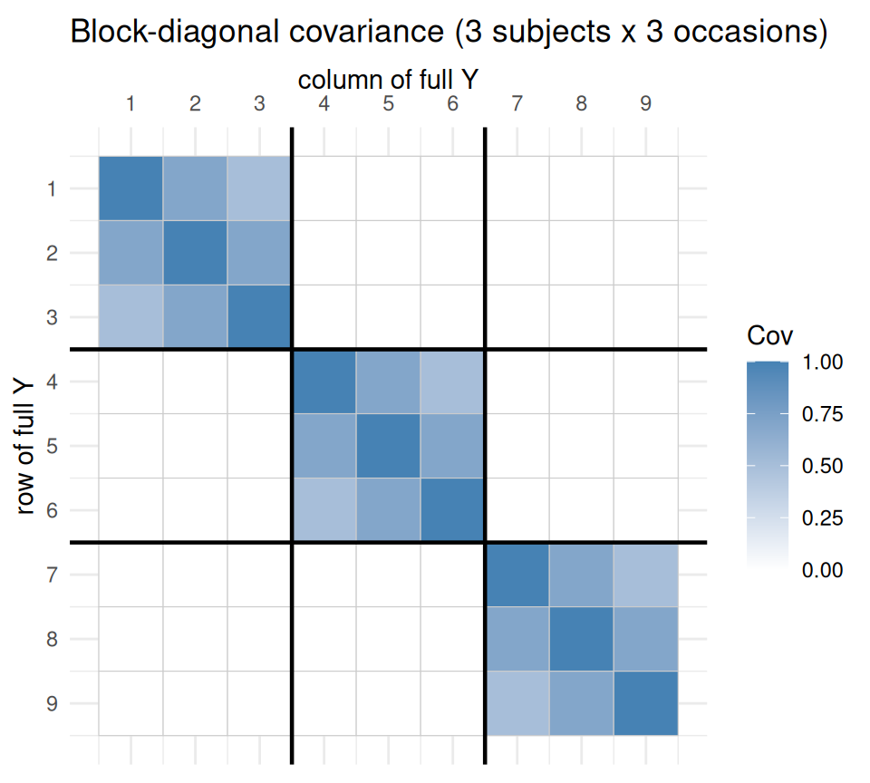

Dense blocks on the diagonal are the within-subject covariances $\Sigma_1, \Sigma_2, \Sigma_3$. The white off-diagonal blocks are zero: different subjects are independent.

## The Two Key Components

| Component | Expression | Meaning |
| --- | --- | --- |
| Mean structure | $E(\mathbf{Y}_{i}) = \mathbf{X}_{i}\boldsymbol{\beta}$ | How the average response changes |
| Covariance structure | $\mathrm{Cov}(\mathbf{Y}_{i}) = \Sigma_i$ | How measures are correlated |

$\Sigma_i = \operatorname{Cov}(\mathbf{Y}_i)$ is the within-subject covariance of the response (unstructured for now); we decompose it once random effects appear in Ch. 8.

# Distributional Assumptions

## The Multivariate Normal Assumption

We assume the vector of responses for subject $i$ is multivariate normal:

$$\mathbf{Y}_i \sim N_{n_i}(\mathbf{X}_i\boldsymbol{\beta}, \Sigma_i)$$

## Why Multivariate Normal?

- A **working assumption** for convenience, not a law of nature
- Makes it easy to derive estimators for $\boldsymbol{\beta}$ and $\Sigma_i$ and to build tests
- **Not strictly required**: inference is generally robust to non-normality
- What matters more: the mean and covariance structure (covered next)

## Verifying the Assumption

Unlike the univariate case, it is very difficult to formally verify the multivariate normal assumption.

Formal statistical tests exist but are often unhelpful, as they can detect departures that are not substantively important.

## Practical Graphical Checks

| Check | Purpose |
| --- | --- |
| Histograms of residuals | Assess marginal normality at each time |
| Boxplots of residuals | Identify outliers and skewness |
| Scatterplots of residual pairs | Check for linear trends between times |

**Caveat**: These checks can only provide evidence of departures. They cannot prove the assumption holds.

## Why Normality Is Not Critical

The assumption of multivariate normality is **not as critical** for valid inferences about $\boldsymbol{\beta}$ as the assumptions about:

- **Independence** between subjects
- **Covariance structure** within an individual

Unless departures are very extreme (e.g., highly skewed data), correctly modeling dependence is more important.

## Common Pitfalls

| Pitfall | Why It Matters |
| --- | --- |
| Confusing mean and covariance misspecification | Misspecifying the mean model is a bigger problem |
| Overstating the role of normality | It is a working assumption, not a strict requirement |

## A Note on Notation

For simplicity, we often use:

- $E(\mathbf{Y}_i)$ for $E(\mathbf{Y}_i | \mathbf{X}_i)$
- $\mathrm{Cov}(\mathbf{Y}_i)$ for $\mathrm{Cov}(\mathbf{Y}_i | \mathbf{X}_i)$

We are always referring to the **conditional** distribution given the covariates.

**Check Your Understanding: Part 1a (Dimensions and structure)**

1. For a subject with 5 repeated measurements and 3 covariates (including intercept), what are the dimensions of $\mathbf{Y}_i$ and $\mathbf{X}_i$?
2. Why is the covariance matrix $\boldsymbol\Sigma$ for the full dataset block-diagonal?

**Answers:**

1. $\mathbf{Y}_i$ is $5 \times 1$; $\mathbf{X}_i$ is $5 \times 3$.
2. Because subjects are independent of each other (no correlation between different subjects), only the within-subject blocks have non-zero covariances. The off-diagonal blocks (between subjects) are all zeros.

**Check Your Understanding: Part 1b (Normality)**

3. A colleague says “we must have normally distributed data to use these methods.” How would you respond?

**Answer:**

3. Normality is a working assumption for convenience, but the methods are robust to departures from normality. What matters more is correctly specifying the mean structure and covariance structure.

# Part 2: Descriptive Methods

## Why Visualize First?

Before modeling, we need to understand the patterns in our data.

**Goal**: To see individual trajectories and overall trends.

## The Spaghetti Plot

A **spaghetti plot** connects successive repeated measures for each individual.

**Purpose**: Shows **individual trajectories**, the spread of starting points (between-subject variability), and any outlying subjects or unbalanced/irregular data.

**Caution (FLW Section 3.3)**: The joined-segments plot is not very informative about trends in the *mean* response; between- and within-subject variability is often almost completely obscured. For reading the mean trend, use the **mean-response (mean-trajectory) plot** instead, not the spaghetti plot.

## Spaghetti Plot: Code

```r
# Load packages
library(dplyr)
library(ggplot2)

# Create mock longitudinal data
set.seed(123)
data_long <- tibble(
  subject = rep(1:20, each = 5),
  time = rep(1:5, times = 20),
  response = rnorm(100, mean = 50 + 2*time + 0.5*subject, sd = 5)
)

# Create the plot
ggplot(data_long, aes(x = time, y = response, group = subject)) +
  geom_line(alpha = 0.6) +
  geom_point(alpha = 0.6) +
  labs(title = "Spaghetti Plot", x = "Time", y = "Response") +
  theme_minimal()
```

## Spaghetti Plot: Code

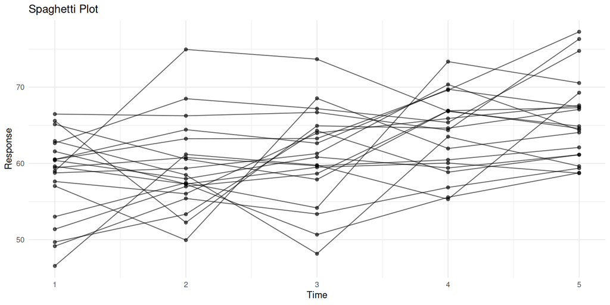

## The Mean Trajectory Plot

A **mean trajectory plot** reveals the overall trend in the data.

**Purpose**: Shows the **overall trend** of the group and a confidence interval for that trend.

## Mean Trajectory Plot: Code

```r
# Summarize data
summary_data <- data_long %>%
  group_by(time) %>%
  summarize(
    mean_response = mean(response),
    sd_response = sd(response),
    n = n(),
    se_response = sd_response / sqrt(n)
  )

# Create the plot with a ribbon for uncertainty
ggplot(summary_data, aes(x = time, y = mean_response)) +
  geom_line(color = "blue", linewidth = 1.5) +
  geom_point(color = "blue", size = 3) +
  geom_ribbon(aes(ymin = mean_response - 1.96 * se_response,
                  ymax = mean_response + 1.96 * se_response),
              alpha = 0.2, fill = "blue") +
  labs(title = "Mean Trajectory with 95% CI", x = "Time", y = "Mean Response") +
  theme_minimal()
```

**Interpretation:** The blue line shows the average response at each time point across all 20 subjects. The shaded ribbon represents a 95% confidence interval for the mean. The upward slope indicates that, on average, the response increases by about 2 units per time point. The narrow confidence interval reflects relatively precise estimation of the mean trajectory. This plot complements the spaghetti plot by summarizing the overall trend while hiding individual variation.

## Mean Trajectory Plot: Code

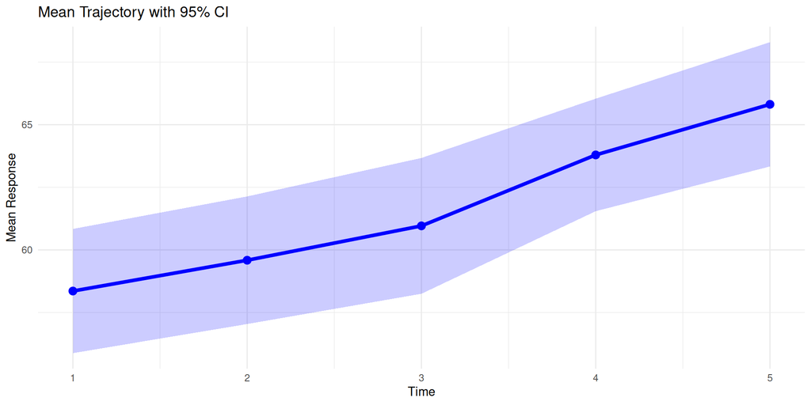

## The Correlation Heatmap

A **correlation heatmap** shows pairwise correlations between repeated measures.

**Purpose**: Shows how the **correlation decays over time**. Do measurements far apart in time have a lower correlation?

**Note**

This heatmap is an instructor-added exploratory device, not one of the FLW Section 3.3 descriptive plots (which are time plots of the raw data, mean-response plots, and smoothing via moving averages or lowess). FLW introduces correlation and correlation decay later, under Section 3.5 “Modeling the Covariance”; we show the heatmap here to bridge into that section.

## Correlation Heatmap: Code

```r
# Load packages
library(tidyr)

# Simulated illustration: genuine AR(1) serial correlation within each subject.
# Each subject's 5 errors follow an AR(1) process, so correlation decays with
# time separation. The population lag-k correlation is 0.8^k, but the finite-
# sample estimate is weaker at longer lags. rho = 0.8 matches the running AR(1)
# example in L02.
set.seed(667)
n_sub <- 200
phi <- 0.8
ar1_data <- do.call(rbind, lapply(1:n_sub, function(s) {
  err <- as.numeric(arima.sim(model = list(ar = phi), n = 5))
  tibble(subject = s, time = 1:5, response = 50 + 2 * (1:5) + err)
}))

# Pivot data to a wide format
wide_data <- ar1_data %>%
  select(subject, time, response) %>%
  pivot_wider(names_from = time, values_from = response) %>%
  select(-subject)

# Calculate correlation matrix
cor_matrix <- cor(wide_data, use = "pairwise.complete.obs")

# Tidy matrix for plotting
cor_long <- cor_matrix %>%
  as.data.frame() %>%
  tibble::rownames_to_column("Time1") %>%
  pivot_longer(-Time1, names_to = "Time2", values_to = "Correlation")

# Create the heatmap
ggplot(cor_long, aes(x = Time1, y = Time2, fill = Correlation)) +
  geom_tile() +
  scale_fill_gradient2(low = "red", high = "blue", mid = "white",
                       midpoint = 0, limit = c(-1,1), name = "Correlation") +
  theme_minimal() +
  labs(title = "Correlation Heatmap (AR(1) data)")
```

**Interpretation:** This heatmap displays the correlation matrix for the 5 time points. The diagonal is darkest blue (correlation = 1, since each time point is perfectly correlated with itself). Because the errors were simulated from an AR(1) process, the off-diagonal correlations fade as the time separation grows: adjacent times (lag 1) are strongly correlated, while the most separated pair (times 1 and 5, lag 4) is much weaker. That visible fade away from the diagonal is the signature of serial correlation, exactly the pattern an AR(1) covariance structure is built to capture.

## Correlation Heatmap: Code

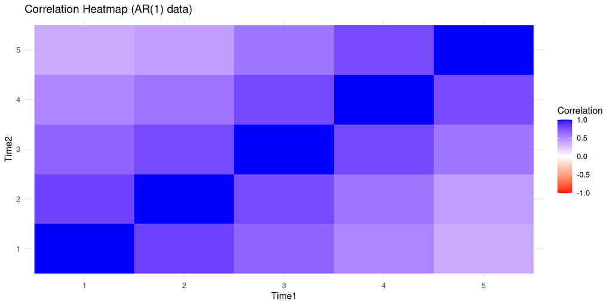

**Check Your Understanding: Part 2a (Reading the plots)**

1. What is the primary purpose of a spaghetti plot versus a mean trajectory plot?
2. In the correlation heatmap, what pattern would you expect if correlation decays with time separation (like AR(1))?

**Answers:**

1. Spaghetti plots show individual trajectories and between-subject variability; mean trajectory plots summarize the overall group trend and its uncertainty.
2. You would see stronger correlations (darker colors) near the diagonal and weaker correlations (lighter colors) in the corners. The cells farthest from the diagonal would be lightest.

**Check Your Understanding: Part 2b (Why visualize first)**

3. Why should you always examine these plots before fitting a model?

**Answer:**

3. These plots reveal the data structure (trends, heterogeneity, potential outliers) and help you choose an appropriate model. You might discover nonlinear trends, unusual subjects, or correlation patterns that inform your covariance structure choice.

# Case Study: TLC Lead-Exposure Trial

## Case Study: From Mock to Real Data

The plots above used simulated data to isolate each idea. Now we run the **same three descriptive views** on a real FLW dataset.

**Data**: Treatment of Lead-Exposed Children (TLC) trial, the running example from Lecture 2 (FLW Ch. 2, Tables 2.2-2.3). We use the **placebo group**: $N = 50$ children, blood-lead level measured at weeks 0, 1, 4, and 6 ($n = 4$ occasions).

**Why placebo**: an untreated group lets us see the natural decay and the within-subject correlation structure without a treatment effect confounding the trend.

```r
library(dplyr)
library(tidyr)
library(ggplot2)

# tlc.csv is WIDE: ID, Treatment Group, then lead level at weeks 0, 1, 4, 6.
# Local-first with a download fallback (FLW ships a header-free, space-delim file).
tlc_file <- "../../data/tlc.csv"
if (!file.exists(tlc_file)) tlc_file <- "data/tlc.csv"
if (file.exists(tlc_file)) {
  tlc <- read.csv(tlc_file)
} else {
  tlc <- read.table("https://content.sph.harvard.edu/fitzmaur/ala2e/tlc-data.txt",
                    header = FALSE,
                    col.names = c("ID", "Treatment.Group",
                                  "Lead.Level.Week.0", "Lead.Level.Week.1",
                                  "Lead.Level.Week.4", "Lead.Level.Week.6"))
}

# Placebo group, one column per occasion -> long format for plotting
weeks <- c(0, 1, 4, 6)
# Select the four weekly lead-level columns BY NAME (robust to column order);
# fall back to the last four columns if a local file uses non-standard names.
lead_cols <- grep("Lead.*Level|Week", names(tlc), ignore.case = TRUE, value = TRUE)
if (length(lead_cols) != 4) lead_cols <- tail(names(tlc), 4)
pbo_wide <- tlc[tlc$Treatment.Group == "P", lead_cols]
colnames(pbo_wide) <- paste0("w", weeks)
pbo_wide$id <- seq_len(nrow(pbo_wide))

pbo_long <- pbo_wide %>%
  pivot_longer(cols = starts_with("w"), names_to = "wk", values_to = "lead") %>%
  mutate(week = weeks[match(wk, paste0("w", weeks))])

nrow(pbo_wide)            # number of placebo children
```

## Case Study: From Mock to Real Data

```
[1] 50
```

```r
range(pbo_long$lead)     # observed blood-lead range
```

```
[1] 13.5 43.3
```

## TLC Placebo: Spaghetti Plot

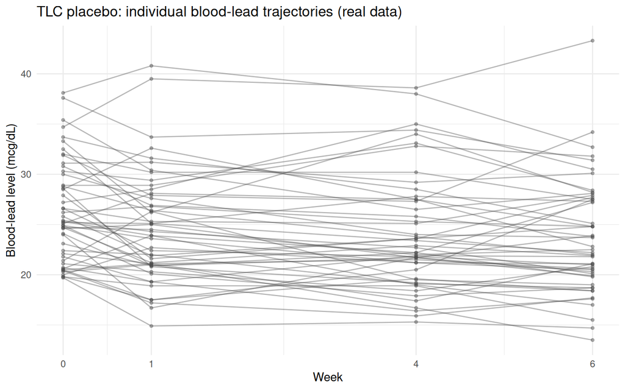

The 50 placebo trajectories spread widely at baseline (the between-subject heterogeneity), and children who start high tend to stay high: relative position persists across weeks. That persistence is the visual signature of **within-subject correlation** the spaghetti plot exposes but cannot quantify.

## TLC Placebo: Mean Trajectory

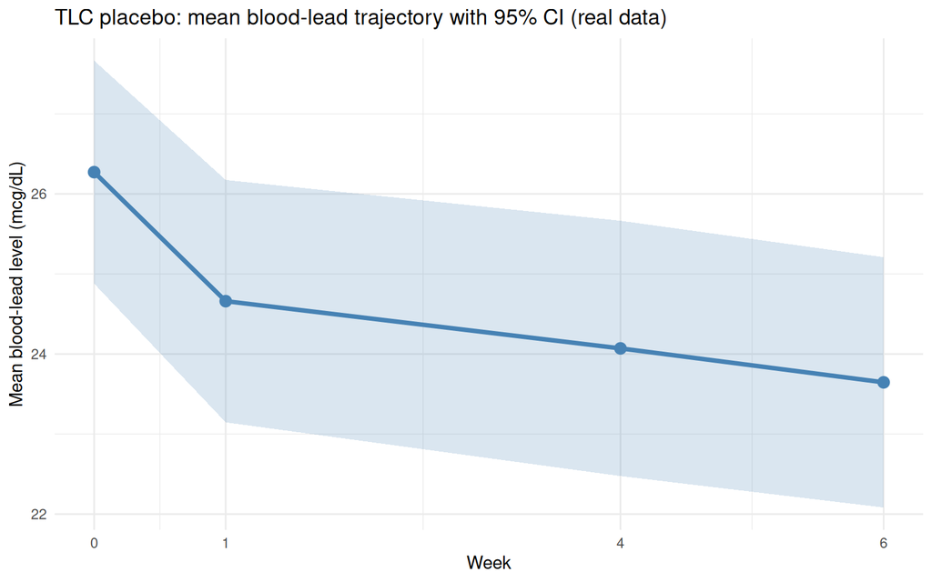

Mean blood-lead drifts down only mildly under placebo, from about 26.3 mcg/dL at week 0 to about 23.6 mcg/dL at week 6. This is the mean-structure picture $E(\mathbf{Y}_i) = \mathbf{X}_i\boldsymbol\beta$ made visual.

**Warning**

The 95% ribbon uses a naive standard error that **ignores within-subject correlation**, so treat it as descriptive only. Proper standard errors require modeling the marginal covariance $\Sigma_i$ (Part 3).

## TLC Placebo: Within-Subject Correlation

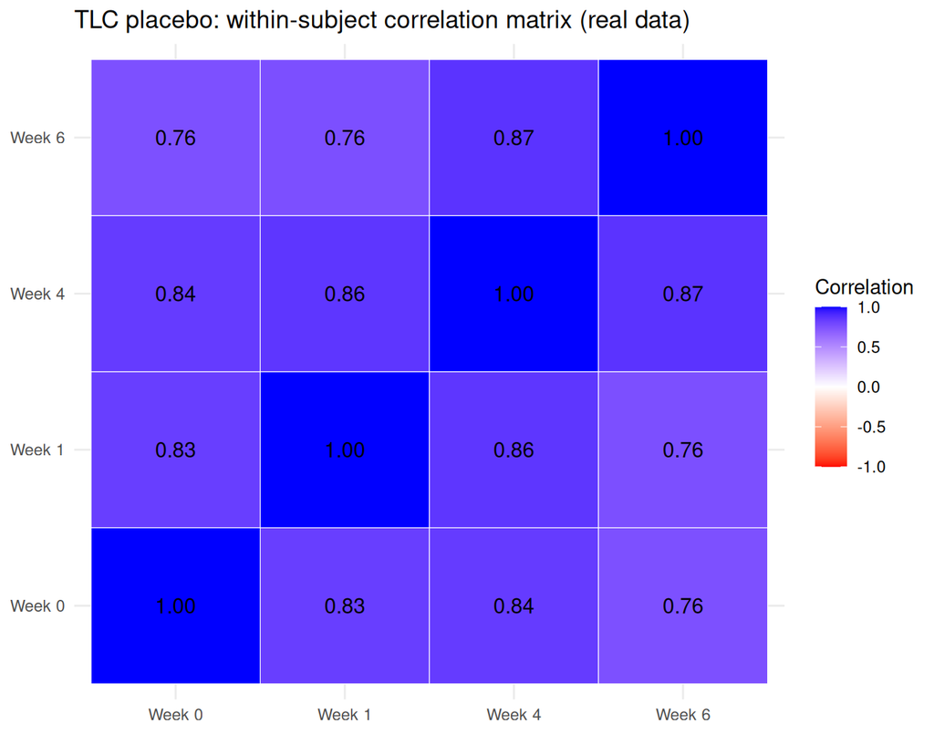

Off-diagonal correlations are high and positive throughout, ranging from about 0.76 to 0.87 (FLW Table 2.3). The dominant signal is strong positive correlation everywhere (between-subject heterogeneity), with a modest decay as the gap between weeks widens. These are exactly the two facts (non-constant structure, decaying correlation) the covariance models in Part 3 are built to capture.

# Part 3: Modeling the Covariance

## Why Model the Covariance?

A **defining feature** of longitudinal data is that repeated responses on the same individual are **correlated**.

This correlation **cannot be ignored**.

## Consequences of Proper Covariance Modeling

| Benefit | Description |
| --- | --- |
| Valid inferences | Correct standard errors and p-values |
| Efficiency | More precise estimates |
| Missing data | Valid estimates under certain conditions |

## Three Covariance Approaches

| Approach | Description |
| --- | --- |
| Unstructured | Completely arbitrary pattern |
| Covariance pattern models | Specific parsimonious structure |
| Random effects | Individual-specific effects induce structure |

## Approach 1: Unstructured Covariance

This approach assumes **no explicit structure** for the covariance.

It estimates the unique variance for each time point and the covariance for every possible pair.

**Key Feature**: Provides a completely **flexible** and arbitrary pattern.

## Drawbacks of Unstructured Covariance

| Issue | Description |
| --- | --- |
| Parameter-heavy | $\frac{n_i(n_i+1)}{2}$ parameters, where $n_i$ = number of occasions (55 for 10 occasions!) |
| Unstable estimates | Small samples lead to instability |
| Data limitations | Cannot accommodate irregular timing or missing data |

## Approach 2: Covariance Pattern Models

This approach places a **specific, parsimonious structure** on the covariance matrix.

Inspired by **time series analysis**.

**Key Idea**: The correlation between repeated measures **decays** as the time separation increases.

## Approach 3: Random Effects

An alternative, **indirect** way to model the covariance.

It accounts for correlation by introducing **individual-specific random effects** into the model.

**Example**: A random intercept represents all unobserved factors that make some subjects naturally higher or lower responders.

## Benefits of Random Effects

| Benefit | Description |
| --- | --- |
| Flexibility and parsimony | Few parameters, realistic patterns |
| Handles irregular data | Natural handling of missing observations |
| Multiple effects | Random intercepts and slopes for richer patterns |

## Summary of Covariance Approaches

| Approach | Pros | Cons |
| --- | --- | --- |
| **Unstructured** | Most flexible | Parameter-heavy, requires complete data |
| **Covariance Pattern** | Parsimonious, handles irregular timing | Assumes a specific pattern |
| **Random Effects** | Flexible, parsimonious, handles missing data | Structure can be too restrictive |

## Covariance Structure Visualized

**Compound Symmetry (CS)**: Constant correlation ($\rho$) for any pair of times.

$$\begin{pmatrix} 1 & \rho & \rho & \rho \\ \rho & 1 & \rho & \rho \\ \rho & \rho & 1 & \rho \\ \rho & \rho & \rho & 1 \end{pmatrix}$$

## Covariance Structure Visualized

**AR(1)**: Correlation decays exponentially as time separation increases ($\rho^k$).

$$\begin{pmatrix} 1 & \rho & \rho^2 & \rho^3 \\ \rho & 1 & \rho & \rho^2 \\ \rho^2 & \rho & 1 & \rho \\ \rho^3 & \rho^2 & \rho & 1 \end{pmatrix}$$

**Check Your Understanding: Part 3a (Unstructured and pattern models)**

1. Why is an unstructured covariance matrix problematic with 10 time points?
2. What is the key difference between compound symmetry (CS) and AR(1) covariance structures?

**Check Your Understanding: Part 3b (Random effects)**

3. How do random effects induce correlation among repeated measures?

**Answer:**

3. Random effects (e.g., a random intercept $b_i$) represent subject-specific deviations that are shared across all measurements for that subject. Since the same $b_i$ affects all of subject $i$’s responses, it creates positive correlation among them.

# Part 4: Historical Approaches

## Three Classical Approaches

| Method | Description |
| --- | --- |
| Summary Measures | Reduce to a single value |
| Univariate Repeated Measures ANOVA | Extension of ANOVA |
| MANOVA | Multivariate analysis of variance |

## Why We Do Not Use Them Anymore

| Method | Advantage | Disadvantage |
| --- | --- | --- |
| **Summary Measures** | Simple, easy to use | Discards trajectory information |
| **Univariate ANOVA** | Easy to perform | Requires compound symmetry |
| **MANOVA** | No covariance structure required | Cannot handle missing data |

## Method 1: Summary Measures

The simplest approach: reduce repeated measures to a **single summary measure**.

**Examples**: Mean response or regression slope.

**Limitation**: Discards information about individual trajectories.

## Method 2: Univariate Repeated Measures ANOVA

An extension of ANOVA.

**Assumption**: **Compound symmetry** (equal variances and constant correlation).

This is often inappropriate for longitudinal data where correlation typically decays with time separation.

**Solution**: Greenhouse and Geisser (1959) developed an adjustment to correct the F-test.

## Method 3: MANOVA

Treats repeated measures as a single, multi-dimensional outcome.

**Advantage**: Does **not** assume a specific covariance structure; it estimates an **unstructured** matrix.

**Limitation**: Requires a complete set of measurements for every subject.

## The Missing Data Problem in MANOVA

MANOVA requires complete measurements for every subject.

| Subject | Time 1 | Time 2 | Time 3 | Time 4 |
| --- | --- | --- | --- | --- |
| 1 | 12 | 10 | 9 | 11 |
| 2 | 15 | 14 | **-** | 13 |
| 3 | 11 | 12 | 10 | 12 |

Subject 2 would be **dropped** from the analysis.

## Comparison of Covariance Assumptions

| Method | Assumption | Parameters |
| --- | --- | --- |
| Univariate ANOVA | Compound symmetry | 2 |
| MANOVA | Unstructured | Many |
| Modern methods | Realistic and parsimonious | Few |

# Part 5: Summary

## Common Mistakes to Avoid

- **Focusing only on the mean structure**: The covariance structure is equally important. Misspecifying it leads to incorrect standard errors and invalid inference, even if your mean model is correct.
- **Using unstructured covariance by default**: While flexible, unstructured covariance requires many parameters and cannot handle missing data or irregular timing. Consider parsimonious alternatives (CS, AR(1), random effects).
- **Applying MANOVA with incomplete data**: MANOVA drops subjects with any missing observations. This wastes data and can introduce bias if missingness is related to the outcome.
- **Assuming compound symmetry without checking**: Univariate repeated measures ANOVA assumes equal correlations across all pairs. This is often unrealistic, since correlations typically decay with time separation.
- **Confusing the mean and covariance misspecification consequences**: Misspecifying the mean model biases $\hat{\beta}$. Misspecifying the covariance structure affects standard errors but not point estimates (if the mean is correct).

## The Core Components

The general linear model has two parts:

| Component | Expression |
| --- | --- |
| Mean structure | $E(\mathbf{Y}_i) = \mathbf{X}_i\boldsymbol{\beta}$ |
| Covariance structure | $\mathrm{Cov}(\mathbf{Y}_i) = \Sigma_i$ |

## The Main Challenge

**The covariance structure** makes longitudinal analysis unique.

We must account for the non-independence of repeated measures.

Choosing a model for $\Sigma_i$ that is both **flexible** and **parsimonious** is the main challenge.

## Further Reading

- **Fitzmaurice, Laird & Ware (2011), Chapter 3** and its “Further Reading” notes: the primary reference for this lecture.
- **Laird & Ware (1982)**, *Random-effects models for longitudinal data*, Biometrics 38:963-974: the foundational mixed-model paper we build toward in Ch. 8.
- **Greenhouse & Geisser (1959)**, *On methods in the analysis of profile data*, Psychometrika 24:95-112: the classic ANOVA sphericity correction mentioned under historical approaches.
- **Diggle, Heagerty, Liang & Zeger (2002)**, *Analysis of Longitudinal Data* (2nd ed.): complementary treatment of covariance structure and serial correlation.

## What Comes Next?

Upcoming chapters will cover **modern approaches** that are more flexible and robust.

| Topic | Description |
| --- | --- |
| Serial correlation | Accounting for time-ordered dependence |
| Random variation | Modeling individual-specific effects |
| Incomplete data | Handling missing observations |